# Computing Rates and Distributions of Rock Recovery in Subduction Zones

Buchanan Kerswell**<sup>1</sup>, Matthew Kohn<sup>1</sup>, Taras Gerya<sup>2</sup>,

<sup>2</sup>Department of Earth Sciences, ETH-Zürich

October 26 2022

# Acknowledgments

## High performance computing

- [Borah](https://www.boisestate.edu/rcs/hpc/) (Boise State University)
- [Euler](https://scicomp.ethz.ch/wiki/Main_Page) (ETH Zürich).

## Special thanks

- [EFIRE](http://www.geoprisms.org/exterra/e-fire/) (#OIA1545903; GeoPrisms Program)
  - [Matt Kohn](https://www.boisestate.edu/earth/staff-members/matthew-j-kohn/) (Boise State)
  - [Sarah Penniston-Dorland](https://www.geol.umd.edu/~sarahpd/) (UMD)
  - [Maureen Feineman](https://www.ems.psu.edu/directory/maureen-feineman) (Penn State)
- [ISTeP](https://sciences.sorbonne-universite.fr/structures-de-recherche/istep) (Sorbonne Université)
  - [Philippe Agard](http://www.istep.upmc.fr/fr/les_equipes/demo/agard_philippe.html)
  - [Laetitia Le Pourhiet](http://www.istep.upmc.fr/fr/les_equipes/demo/le_pourhiet_laetitia.html)

# Glossary

| Term | Description |
| --- | --- |
| markers | numerical objects representing rock bodies in geodynamic simulations |
| rocks | subduction-related rock samples w/ PT estimates and other metadata |
| recovery | detachment of rock bodies from the subducting plate (max PT$^*$) |
| recovery mode | region in PT space with high sample density [high frequency] |
| PT | pressure temperature |
| HP | high pressure |
| OP | oceanic plate |
| UP | upper plate |

# Summary

## Research questions

#### Where are rocks recovered along subduction interface shear zones?

#### How do recovery rates and distributions vary among subduction zones?

#### How do numerical and empirical PT distributions compare?

## Main findings

#### PT grads correlate w/ OP age & UP thickness, while depths correlate w/ velocity

#### Few markers detach from the highest-density regions of natural samples

# Background Where are rocks recovered from? How many?

**Few rocks are recovered, but all come from the interface**

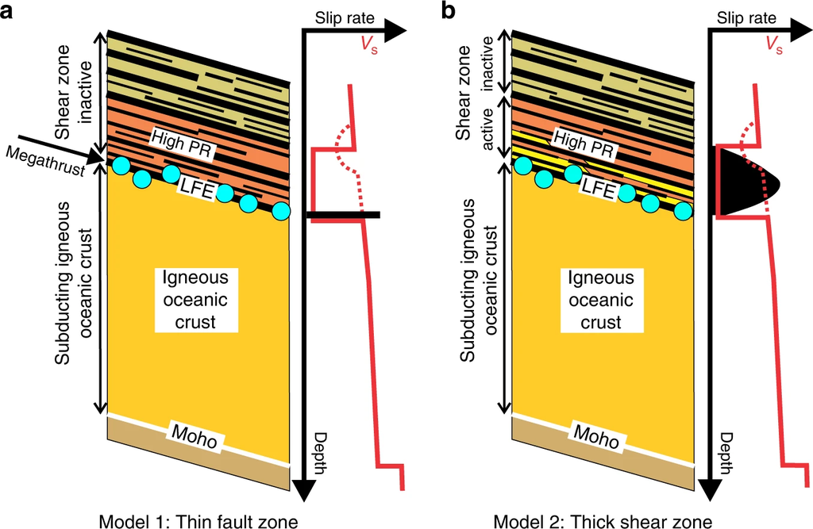

Calvert et al. (2020)

### **The interface**

#### Deformation styles

- Stick-slip [discrete brittle]
- Shear zone [mixed]
- Coupled [distributed viscous]
- Depends on dehydration rxns

#### Seismic properties

- Low velocity zones (LVZs)
  - Few kms thick
  - High $V_p/V_s$ ratio
  - High Poisson ratio

# Background Where are rocks recovered from? How many?

**Geophysical images hint at shear zone structure…**

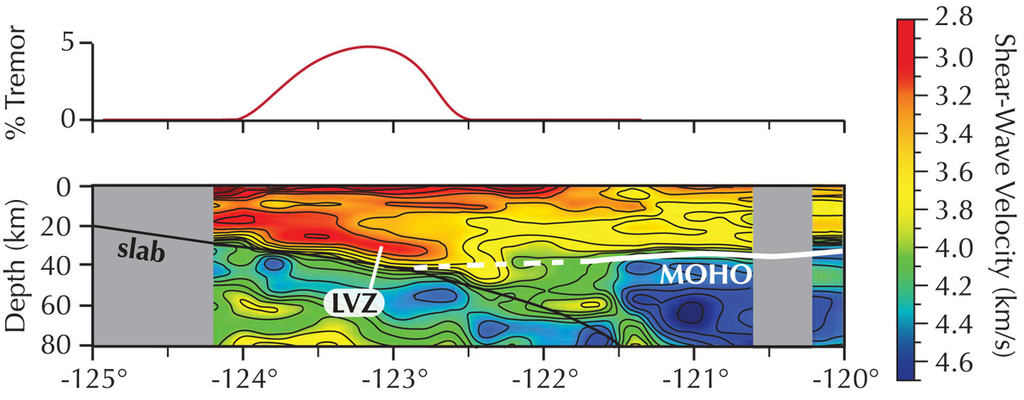

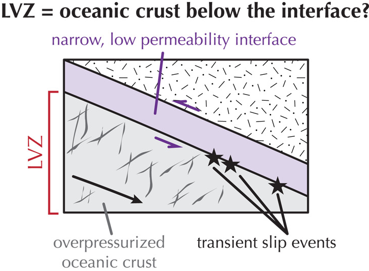

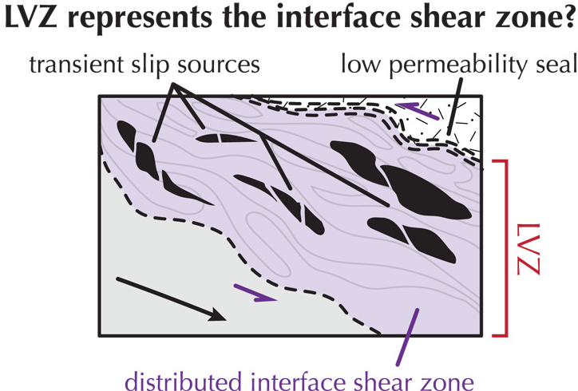

Tewksbury-Christle & Behr (2021)

**…and SZ rocks preserve exquisite detail**

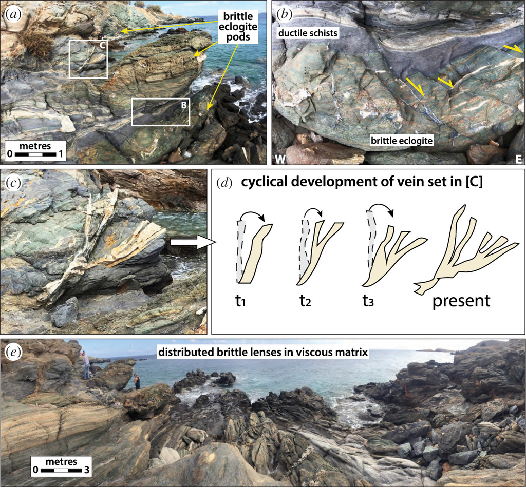

Behr & Bürgmann (2021)

# Background Where are rocks recovered from? How many?

**Recovery is expected at key rheologic transitions…**

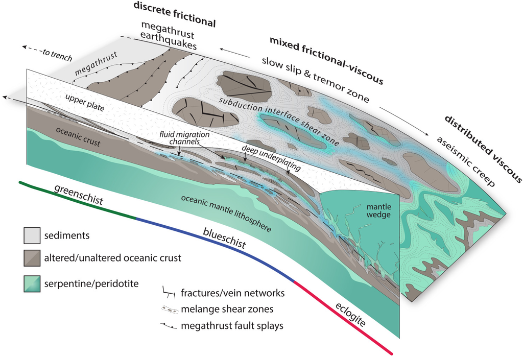

Behr & Bürgmann (2021)

**…and not expected beyond viscous coupling**

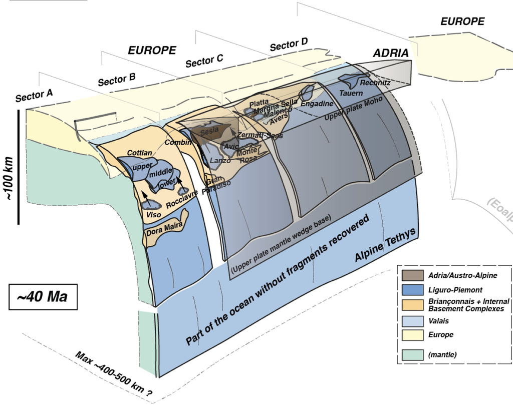

Agard (2021)

# Background Where are rocks recovered from? How many?

**Samples are distributed *pretty* smoothly…**

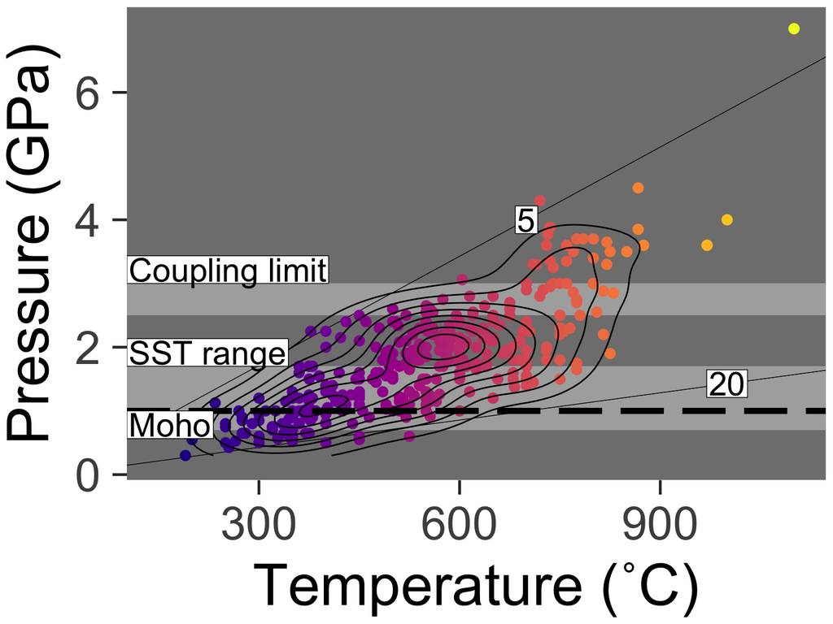

Data from Penniston-Dorland et al. (2015)

**…yet some clusters (modes) are apparent**

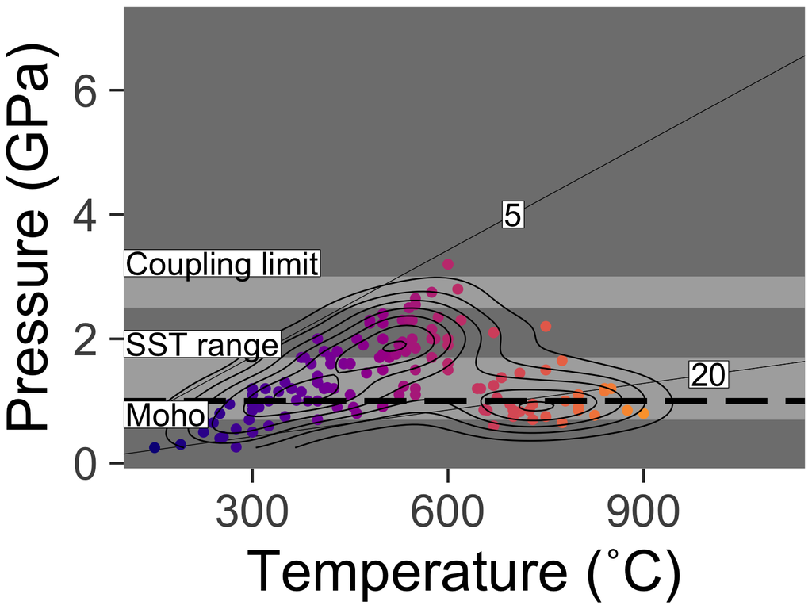

Data from Agard et al. (2018)

# Methods Trace & classify markers in numerical experiments

**Interface rheology controlled by hydrologic model**

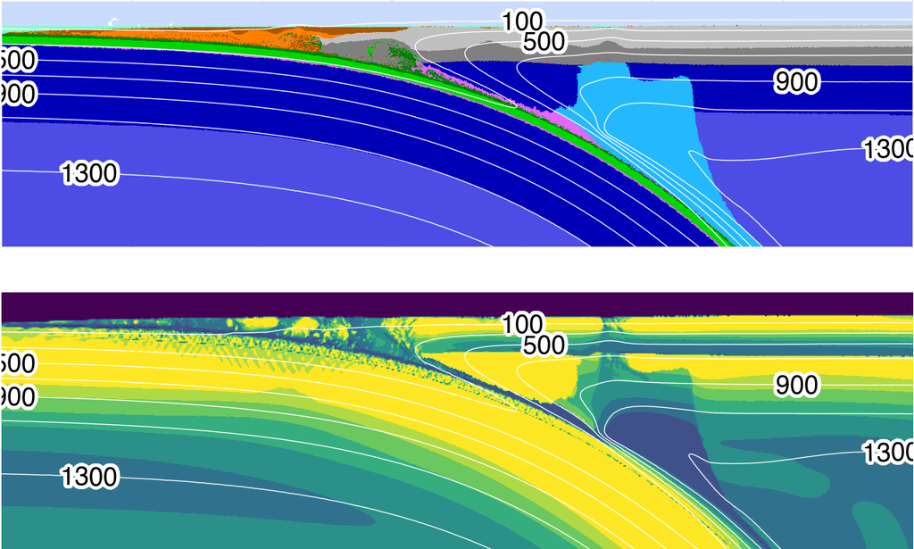

Kerswell et al. (2021)

### **Model setup**

#### Fixed parameters

- Rheologic model
- Hydrologic model
- Material properties
- Boundary conditions

#### Varied parameters

- Velocity (40-100 km/Ma)
- OP age (32-110 Ma)
- UP thickness (46-94 km)

#### Hydrologic model

- Cont. slab dehydration
- Atg forms weak interface

# Methods Trace & classify markers in numerical experiments

**Recognizing recovery is an unsupervised classification problem**

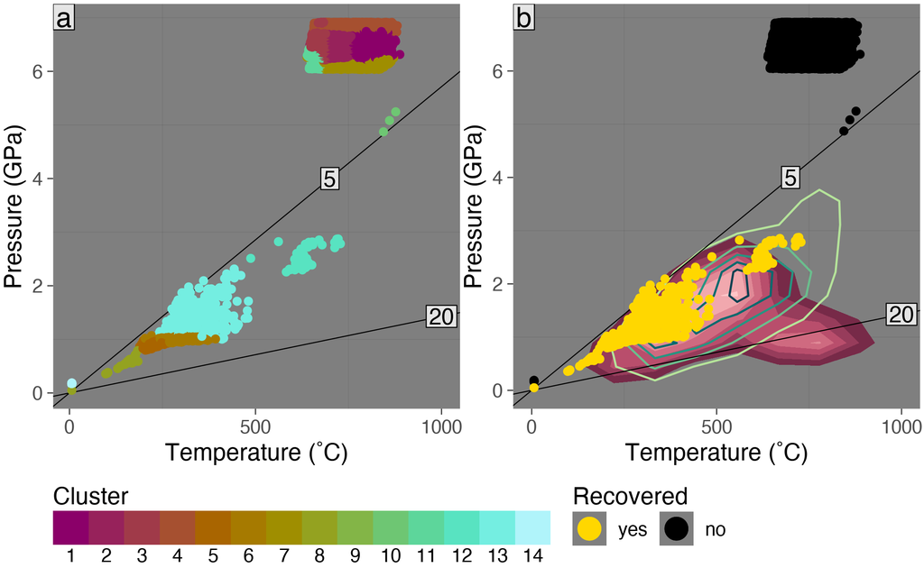

Kerswell et al. (in prep.)

### **Classification**

#### Algorithm

1. Trace markers
2. Get max PTs*
3. Apply clustering
4. Clusters located @:  
   ≥ 3 ˚C/km &  
   ≤ 1300 ˚C &  
   ≤ 3.4 GPa  
   are recovered

#### Uncertainty

- Count: $\pm$ 43 (2 $\sigma$)
- Ratio: $\pm$ 0.23% (2 $\sigma$)

* along prograde path

# Methods Trace & classify markers in numerical experiments

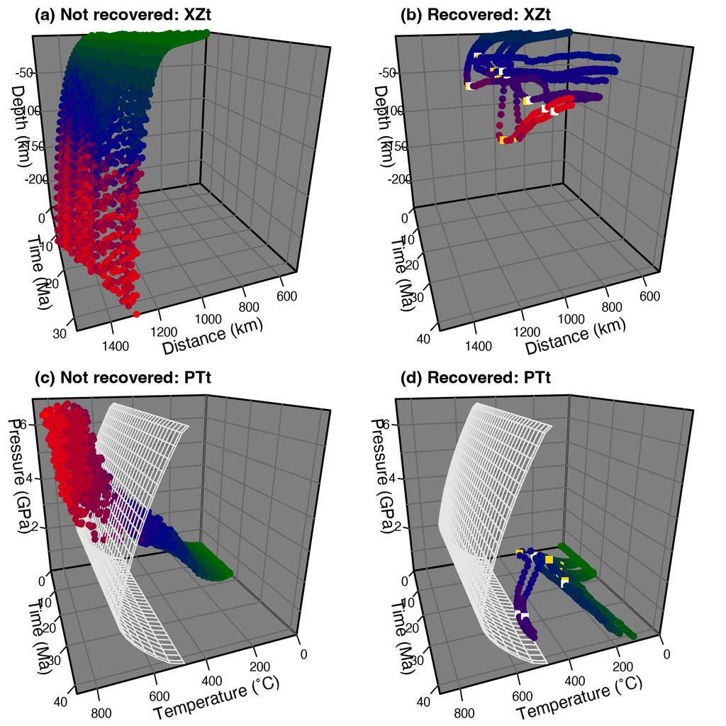

Kerswell et al. (in prep.)

### **Determining maximum PTs of recovered markers**

- Max P&T determined independently
- Heating after peak burial overestimates PT grads
- Most markers have small time gaps bw max P&T

# Results How does recovery vary among subduction zones?

**Stronger fill colors = stronger monotonic correlation**

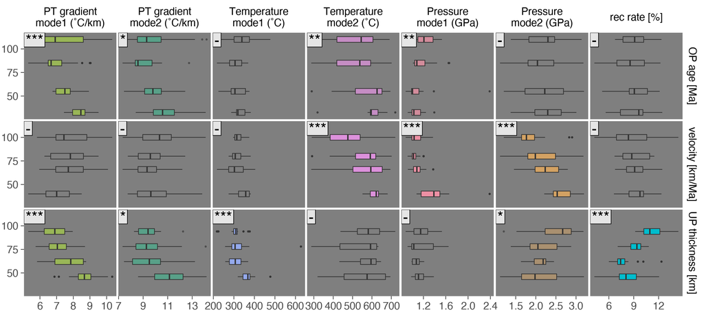

Kerswell et al. (in prep.)

### **Recovery modes vs. initial conditions**

#### Modes

- 1 = most markers
- 2 = deepest markers

#### Correlations

- grads → age & UPT
- depths → velocity
- temps → UPT
- rates → UPT

# Results The marker recovery gap

### Slow slabs = deeper recovery

**All markers**

**Young slow slab**

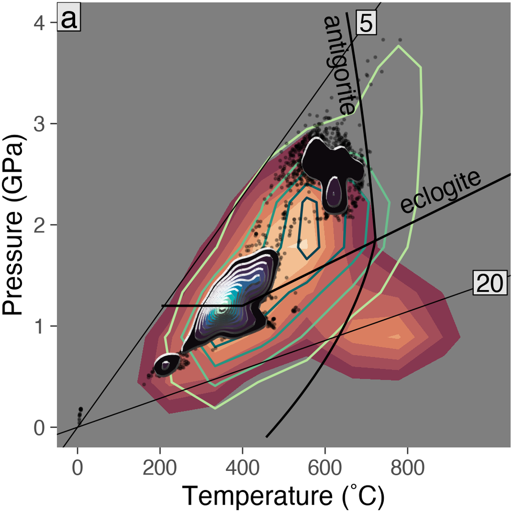

**Old slow slab**

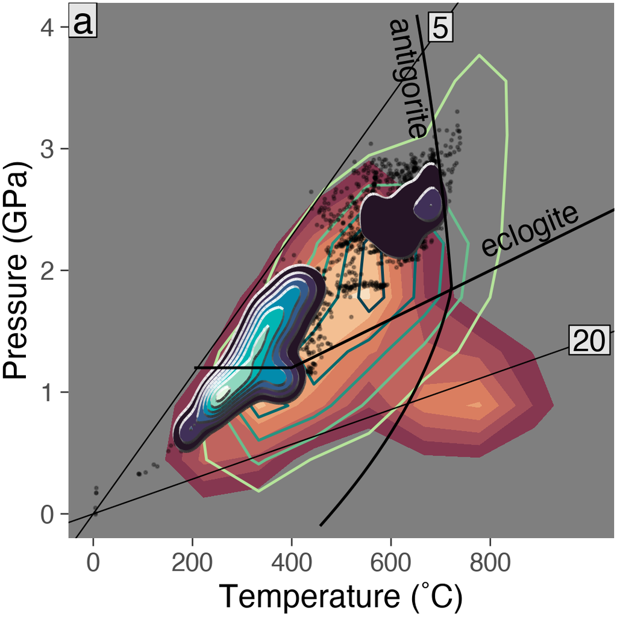

Kerswell et al. (in prep.)

# Results The marker recovery gap

### Fast slabs = shallower recovery

**All markers**

**Young fast slab**

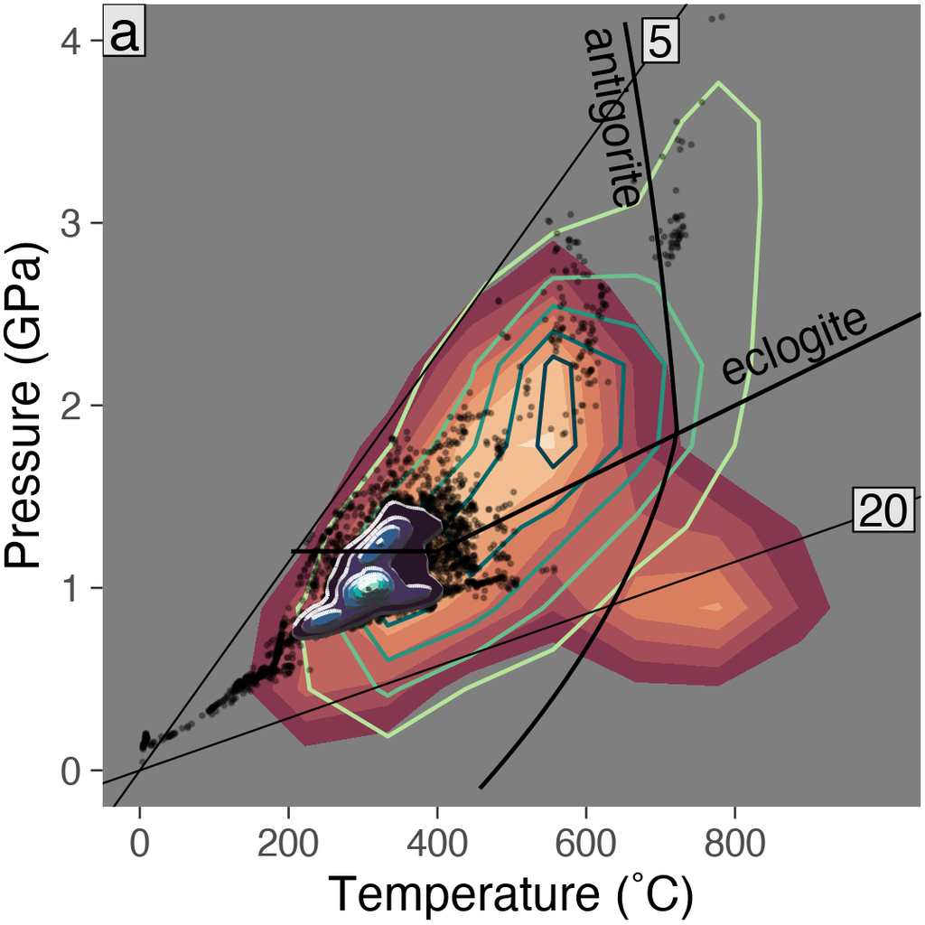

**Old fast slab**

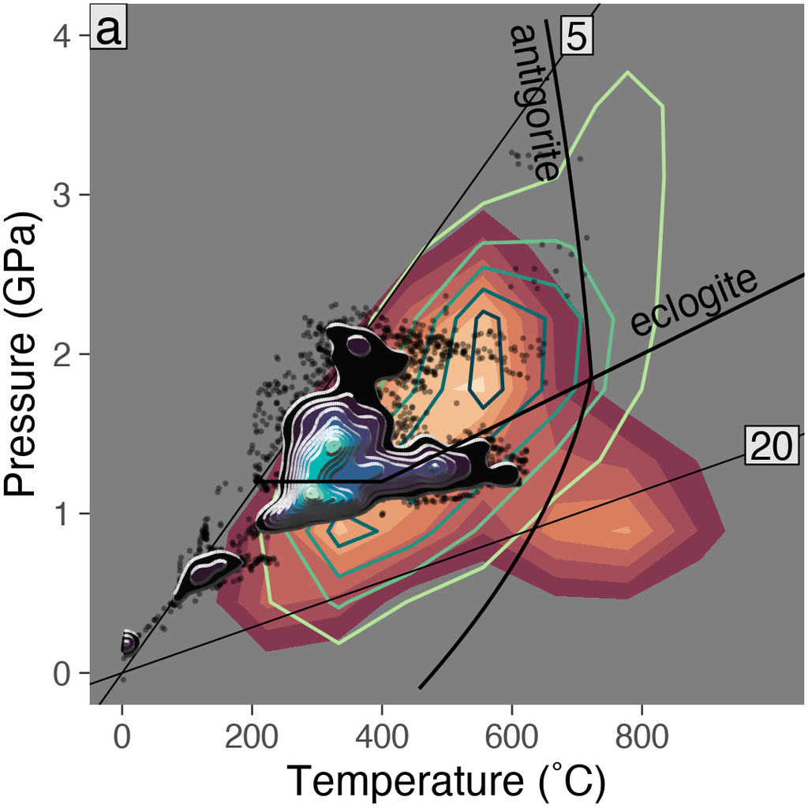

Kerswell et al. (in prep.)

# Results The marker recovery gap

### Thin upper plates = warmer recovery

**All markers**

**Young slab, thin upper plate**

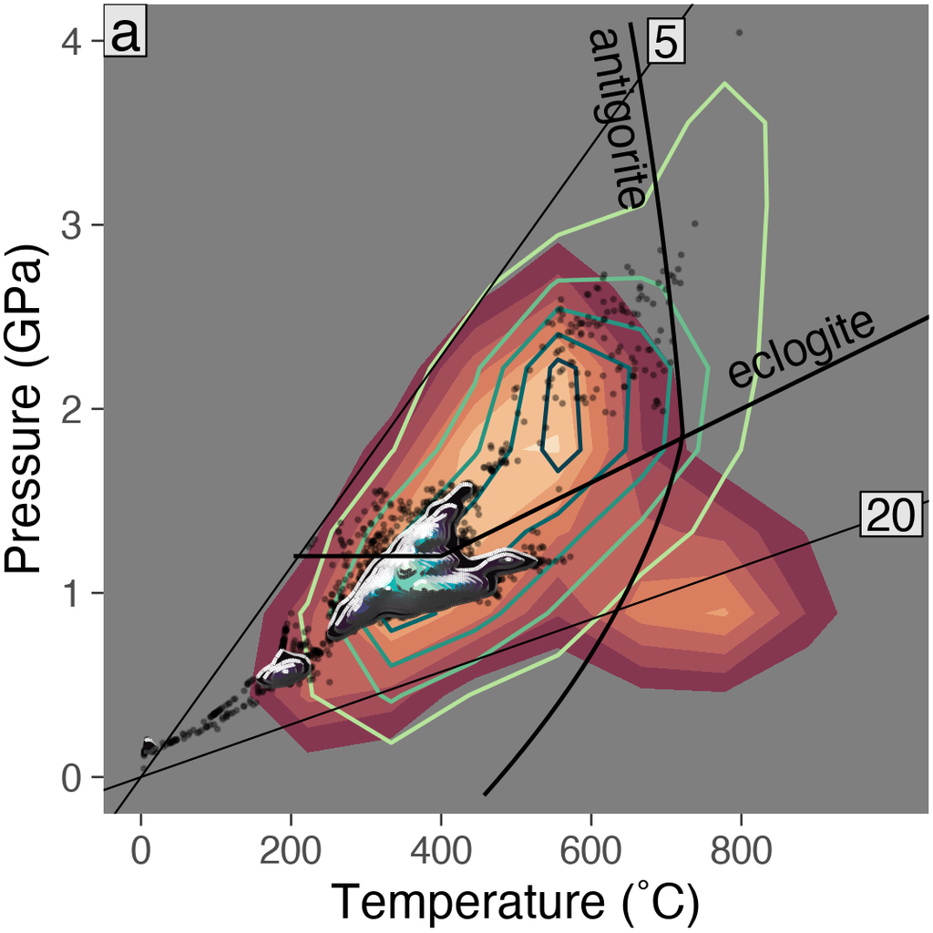

**Old slab, thin upper plate**

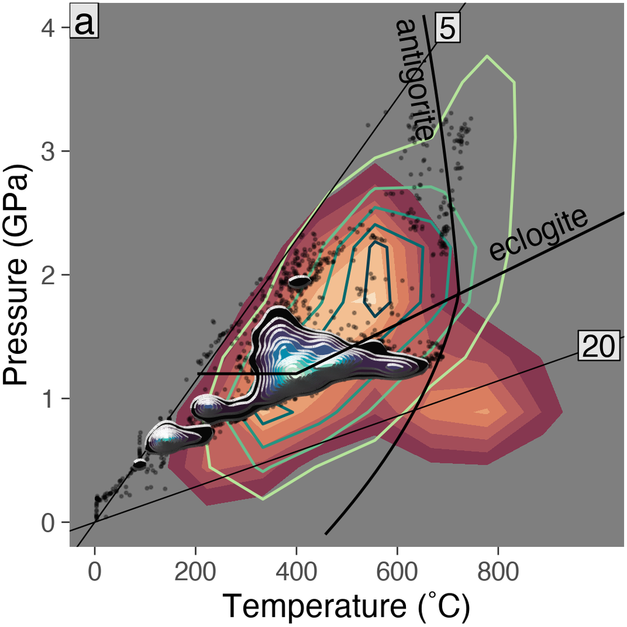

Kerswell et al. (in prep.)

# Results The marker recovery gap

### Thick upper plates = cooler recovery

**All markers**

**Young slab, thick upper plate**

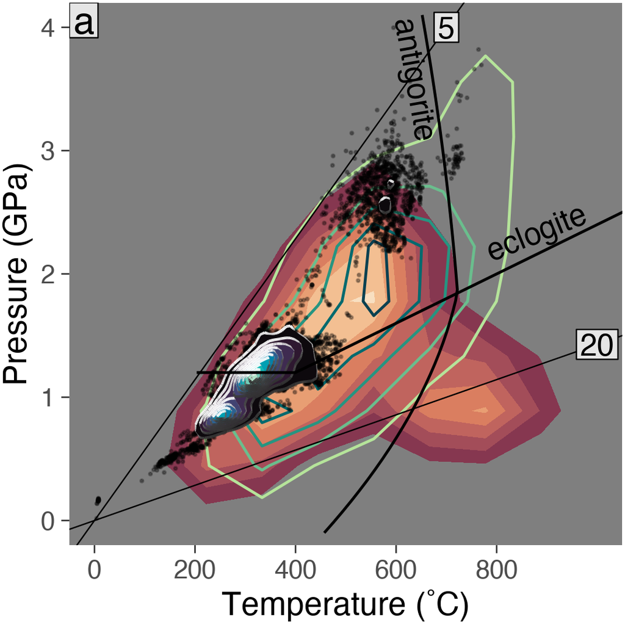

**Old slab, thick upper plate**

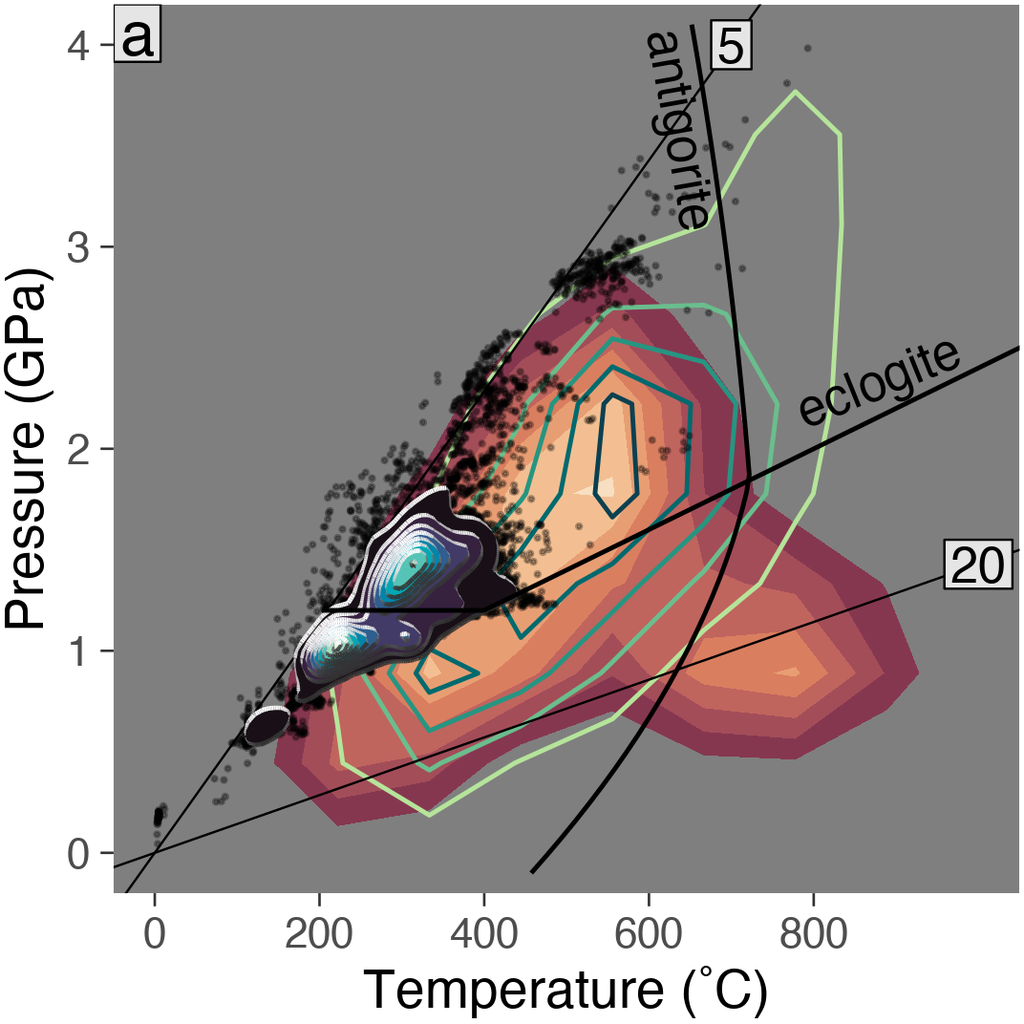

Kerswell et al. (in prep.)

# Conclusions & Implications

### **Recovery depths**

Marker recovery modes correspond with mechanical transitions inferred from seismic imaging

- Underplating/mélange at 1 GPa (e.g. Bostock, 2013)
- Minor recovery near viscous coupling depth at ~2.3 GPa

### **SZ settings**

Marker show appreciable deviations from the rock record except for young, slow OPs with thin UPs

- Increasing average T does not fill in the marker recovery gap
- Recovery rates are not correlated with OP age or velocity
- Recovery rates are poor for thin UP lithospheres

### **Recovery gap**

Across 64 numerical experiments, less than 1% of markers are recovered from 1.8-2.2 GPa and 500-625 ˚C

- Poor implementation of detachment mechanisms (modeling bias)
- Rock PTs are systematically misinterpreted (petrologic bias)
- Rocks are (re)sampled from the same conditions (scientific bias)
- Rocks are recovered early and/or during short-lived events (tectonic bias)

# References

Agard, P. (2021). Subduction of oceanic lithosphere in the alps: Selective and archetypal from (slow-spreading) oceans. *Earth-Science Reviews*, *214*, 103517.

Agard, P., Plunder, A., Angiboust, S., Bonnet, G., & Ruh, J. (2018). The subduction plate interface: Rock record and mechanical coupling (from long to short time scales). *Lithos*, *320-321*, 537–566.

Behr, W. M., & Bürgmann, R. (2021). What’s down there? The structures, materials and environment of deep-seated slow slip and tremor. *Philosophical Transactions of the Royal Society A*, *379*(2193), 20200218.

Bostock, M. (2013). The moho in subduction zones. *Tectonophysics*, *609*, 547–557.

Calvert, A., Bostock, M., Savard, G., & Unsworth, M. (2020). Cascadia low frequency earthquakes at the base of an overpressured subduction shear zone. *Nature Communications*, *11*(1), 1–10.

Kerswell, B., Kohn, M., & Gerya, T. (2021). Backarc lithospheric thickness and serpentine stability control slab-mantle coupling depths in subduction zones. *Geochemistry, Geophysics, Geosystems*, *22*(6), e2020GC009304.

Penniston-Dorland, S., Kohn, M., & Manning, C. (2015). The global range of subduction zone thermal structures from exhumed blueschists and eclogites: Rocks are hotter than models. *Earth and Planetary Science Letters*, *428*, 243–254.

Tewksbury-Christle, C., & Behr, W. (2021). Constraints from exhumed rocks on the seismic signature of the deep subduction interface. *Geophysical Research Letters*, *48*(18).